# DATA2002_Report

500633434

2022-09-16

# 1 Introduction

## 1.1 Is this a random sample of DATA2x02 students?

I consider this data is not a random sample of DATA2x02 students. The definition of random sample is “A simple random sample is a subset of a statistical population in which each member of the subset has an equal probability of being chosen. A simple random sample is meant to be an unbiased representation of a group.”, base on the definition, the data is not a random sample. The data from survey was completed by the student from DATA2002 and DATA2902, and the survey was posted on ED, which will occur bias in the data because most of the student will not look through the post on ed, and they were not active on the live lecture, so they wouldn’t know there was a survey that post on ED, so the survey was not completed by all the students who takes DATA2x02.As a result, this is not a random sample.

## 1.2 What are the potential biases? Which variables are most likely to be subjected to this bias?

The possible biased are: - Non-response bias and sample bias, which trigger by those students who never attend the lecture and never check the post on ED; - selection bias, this bias is because of those student who took the survey are tend to get a high score, which means they will attend every lecture and provide a high quality of every assignment, so there will be some influence to the answer of questions: “have you ever use R before DATA2x02”. - Measurement or design bias: the student who took the survey may have a thought that the survey will have some scores that correlate to the mark of this course, so they will answer some of the question in the way that base on the question and the way that they think what are the questioner expect. For example: “the role that work as part of a team”,“how much time do you spend on DATA2x02 every week” - Question order bias: the question in the order is messed up. Students will remember how they answer for each question, and they want to response all the questions in a consistent way. With a survey with no order, people who are taking the survey will get tired and they may quit the survey or answer the question that doesn’t follow their heart.

## 1.3 Which questions needed improvement to generate useful data

The most obvious one is the question that ask about the height and the shoes size. Students who took the survey will have different answer with different unit. For the question of height, some students will use centimeter, some will use meter, some will use feet. For the question of shoes size, some may use EU unit like 40, 42, some may use US or AUS unit like 8, 8.5, 7.5. In this case, this will occur bias in the data. So, the questioner should set the unit of these kind of questions. Furthermore, on the question “what you watch or listen on the way to school”, there should be more options for international students. Like the students from China, they may watch TitTok, or the student from other country, they may watch Instagram or Twitter on the way to school.

# 2 Specific hypothesis tests

## 2.1 load the packages

```r
library("tidyverse")
library("gt")
library("pwr")
library("visdat")
library("janitor")
library("remotes")
library("ggpubr")
library("knitr")
library("ggplot2")
```

## 2.2 data cleaning

```r
x = readr::read_tsv("C:/Users/cyk03/Desktop/data2002/lab/DATA2002asm1/DATA2x02 survey (2022) - Form responses 1 (1).tsv", col_names = TRUE, na = c("", "NA", "n/a"))
cleandat = remove_empty(x)
```

```
## value for "which" not specified, defaulting to c("rows", "cols")
```

```r
cleandat = cleandat %>%
  janitor::clean_names()

cleandat
```

```
## # A tibble: 207 × 38
##    timestamp     have_…¹ what_…² how_t…³ how_d…⁴ what_…⁵ if_yo…⁶ how_d…⁷ how_o…⁸
##    <chr>         <chr>   <chr>   <chr>   <chr>   <chr>   <chr>     <dbl>   <dbl>
##  1 15/08/2022 1… No      With p… "1,58"  I neve… I neve… 50-100…      10       3
##  2 15/08/2022 1… Yes     Colleg… "165"   Bus, W… Music,… 100           4       8
##  3 15/08/2022 1… Yes     Share … "180"   Walk    Music   $700          7       8
##  4 15/08/2022 1… Yes     With p… "182"   Train,… Music,… 200          10       2
##  5 15/08/2022 1… Yes     With p… "173"   Train   Music,… 5             7       2
##  6 15/08/2022 1… No      With p… "163"   Bus     Music   dont k…       2      10
##  7 15/08/2022 1… No      Share … "183cm" Bus     I don'… 2000          5       6
##  8 15/08/2022 1… Yes     With p… "6'3\"" Walk    I don'… 150           9       3
##  9 15/08/2022 1… No      With p… "166"   Train   I don'… on ave…      10       6
## 10 15/08/2022 1… Yes     With p… "165"   Train,… Music,… 3000          8       4
## # … with 197 more rows, 29 more variables:
## #   how_many_hours_a_week_do_you_spend_studying <dbl>,
## #   do_you_watch_and_or_read_the_news_regularly <chr>,
## #   what_is_your_study_load <chr>, do_you_work <chr>,
## #   when_youre_in_a_zoom_lab_how_often_do_you_turn_your_camera_on <chr>,
## #   what_is_your_favourite_social_media_platform <chr>,
## #   what_is_your_gender <chr>, …
## # ℹ Use `print(n = ...)` to see more rows, and `colnames()` to see all variable names
```

```r
old_names = colnames(cleandat)
```

[figure not shown]

```r
visdat::vis_miss(x)
```

## 2.3 rename the colnmns

```r
new_names = c("timestamp","covid_positive","living_arrangements","height","uni_travel_method","uni_travel_listen","spain_budget","feel_overseas","feel_anxious","study_hrs","read_news","study_load","work","lab_zoom","social_media","gender","sleep_time","wake_time","random_number","steak_preference","dominant_hand","normal_advanced","exercise_hrs","employment_hrs","city","weekly_saving","hourly_plan","weeks_behind","assignment_on_time","used_r_before","team_role","data2x02_hrs","social_media_hrs","uni_year","sport","wam","shoe_size","decade_selection")
# overwrite the old names with the new names:
colnames(cleandat) = new_names
# combine old and new into a data frame:
name_combo = bind_cols(New = new_names, Old = old_names)
name_combo %>% gt::gt()
```

| New | Old |
| --- | --- |
| timestamp | timestamp |
| covid_positive | have_you_ever_tested_positive_to_covid_19 |
| living_arrangements | what_are_your_current_living_arrangements |
| height | how_tall_are_you |
| uni_travel_method | how_do_you_get_to_university |
| uni_travel_listen | what_do_you_watch_listen_to_on_the_way_to_university |
| spain_budget | if_you_were_to_spend_two_weeks_travelling_around_spain_how_much_would_you_budget_towards_spending_each_day_all_inclusive_accomodation_activities_food_drink_entertainment |
| feel_overseas | how_do_you_feel_about_the_idea_of_travelling_overseas |
| feel_anxious | how_often_would_you_say_you_feel_anxious_on_a_daily_basis |
| study_hrs | how_many_hours_a_week_do_you_spend_studying |
| read_news | do_you_watch_and_or_read_the_news_regularly |
| study_load | what_is_your_study_load |
| work | do_you_work |
| lab_zoom | when_youre_in_a_zoom_lab_how_often_do_you_turn_your_camera_on |
| social_media | what_is_your_favourite_social_media_platform |
| gender | what_is_your_gender |
| sleep_time | what_time_did_you_go_to_sleep_last_night |
| wake_time | what_time_did_you_wake_up_this_morning |
| random_number | pick_a_number_at_random_between_0_and_9 |
| steak_preference | how_do_you_like_your_steak_cooked |
| dominant_hand | what_is_your_dominant_hand |
| normal_advanced | which_unit_are_you_enrolled_in |
| exercise_hrs | on_average_how_many_hours_each_week_do_you_spend_exercising |
| employment_hrs | how_many_hours_a_week_on_average_do_you_work_in_paid_employment |
| city | what_city_and_suburb_do_you_currently_reside_in |
| weekly_saving | on_average_how_much_are_you_able_to_save_per_week_in_aud |
| hourly_plan | in_an_average_week_during_the_semester_do_you_make_an_hourly_plan_of_your_day |
| weeks_behind | in_an_average_semester_how_many_weeks_on_average_between_all_subjects_are_you_behind_on_lectures_labs_and_tutorials |
| assignment_on_time | do_you_submit_assignments_on_time |
| used_r_before | have_you_ever_used_r_before_starting_data2x02 |
| team_role | what_kind_of_role_active_or_passive_do_you_think_you_are_when_working_as_part_of_a_team |
| data2x02_hrs | how_much_time_do_you_usually_spend_on_data2x02_each_week |
| social_media_hrs | how_many_hours_do_you_spend_on_social_media_per_day |
| uni_year | which_year_of_university_are_you_currently_in |
| sport | which_sports_do_you_play_most_often |
| wam | what_is_your_wam |
| shoe_size | what_is_your_shoe_size |
| decade_selection | if_you_used_a_time_machine_to_travel_into_the_past_which_20th_century_decade_would_you_choose |

```r
cleandat = cleandat %>% mutate(
  gender = stringr::str_to_title(gender),
  gender = recode(gender,
                  `f` = "Female",
                  `F` = "Female",
                  `Femaile` = "Female",
                  `Female` = "Female",
                  `femaile` = "Female",
                  `female` = "Female",
                  `Woman` = "Female",
                  `M` = "Male",
                  `Male` = "Male",
                  `male` = "Male"),
  gender = forcats::fct_lump(gender, n = 2))
table(cleandat$gender)
```

```
##
## Female   Male  Other
##     94    106      5
```

```r
table(cleandat$used_r_before)
```

```
##
##  No Yes
##  19 188
```

## 2.4 Is there correlation between gender and use_r_before

There is a general phenomenon that most of the subject that relate to coding, are mostly chosen by male, there are nearly a female will choose a subject like that. Base on the survey, i want to find out that if this phenomenon is true or not

### 2.4.1 Hypothesis:

$$H0: \text{The vote for used_r_before
are homogenous}$$
$$H1: \text{The
vote for used_r_before are not homogenous}$$

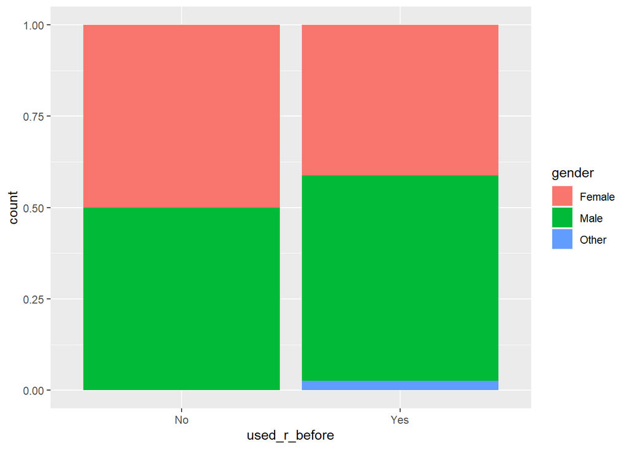

```r
cleandat = na.omit(cleandat)
p1 = ggplot(cleandat,aes(x = used_r_before, fill = gender))
p1 + geom_bar(position = "fill")
```

```r
userTable = table(cleandat$gender, cleandat$used_r_before)
userTable
```

```
##
##          No Yes
##   Female  6  47
##   Male    6  64
##   Other   0   3
```

### 2.4.3 chi-suqare test

```r
chisq.test(userTable, correct = TRUE)
```

```
##
##  Pearson's Chi-squared test
##
## data:  userTable
## X-squared = 0.58808, df = 2, p-value = 0.7452
```

### 2.4.4 p-value

```r
pval = pchisq(0.2584, 2, lower.tail = TRUE)
pval
```

```
## [1] 0.1212018
```

### 2.4.5 Conclusion

The p-value is greater than 0.05, therefore we will accept the null hypothesis and make a conclusion that the usage of R before DATA2x02 are homogeneous between male and female.

## 2.5 Will gender be a factor that student who make hourly plan?

```r
table(cleandat$gender, cleandat$hourly_plan)
```

```
##
##          1-3 days 4-6 days Always Never
##   Female       18        6      7    22
##   Male         20        9     10    31
##   Other         1        0      1     1
```

### 2.5.1 clean data, using drop_na function

```r
ghdat = cleandat %>%
  drop_na(hourly_plan) %>%
  drop_na(gender) %>%
  mutate(hourly_plan) %>%
  mutate(gender)
```

### 2.5.2 clean hourly_plan data and change the column name and add the data together

```r
cleandat = cleandat %>% mutate(
  hourly_plan = stringr::str_to_title(hourly_plan),
  hourly_plan = recode(hourly_plan,
                  `1-3 Days` = "yes",
                  `4-6 Days` = "yes",
                  `Always` = "yes",
                  `Never` = "No"),
  hourly_plan = forcats::fct_lump(hourly_plan, n = 8))
table(cleandat$hourly_plan)
```

```
##
##  No yes
##  54  72
```

### 2.5.3 table of gender and hourly_plan

```r
ghtable = table(cleandat$gender, cleandat$hourly_plan)
ghtable
```

```
##
##          No yes
##   Female 22  31
##   Male   31  39
##   Other   1   2
```

```r
ghdata = ghdat[, c("hourly_plan", "gender")] %>% filter(gender %in% c("Female", "Male"))
```

### 2.5.4 plot of “gender vs hourly plan”

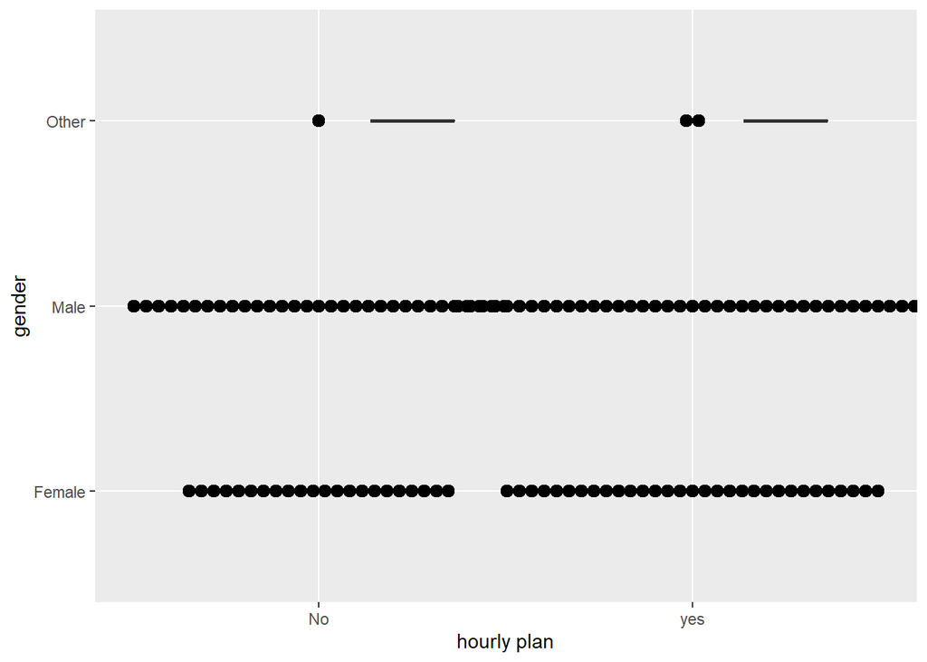

```r
cleandat %>%
  ggplot() +
  aes(x = hourly_plan, y = gender) +
  geom_boxplot(coef = 10) +
  geom_dotplot(stackdir = "center", binaxis = "y") +
  labs(y = "gender", x = "hourly plan")
```

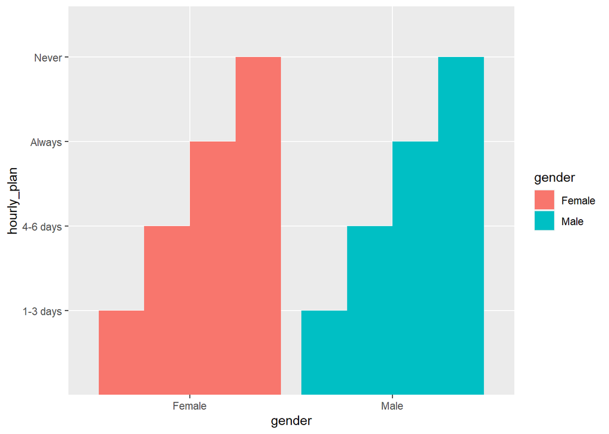

```r
ggplot(ghdata, aes(x = gender, y = hourly_plan, fill = gender)) + geom_bar(stat = "identity", position = position_dodge())
```

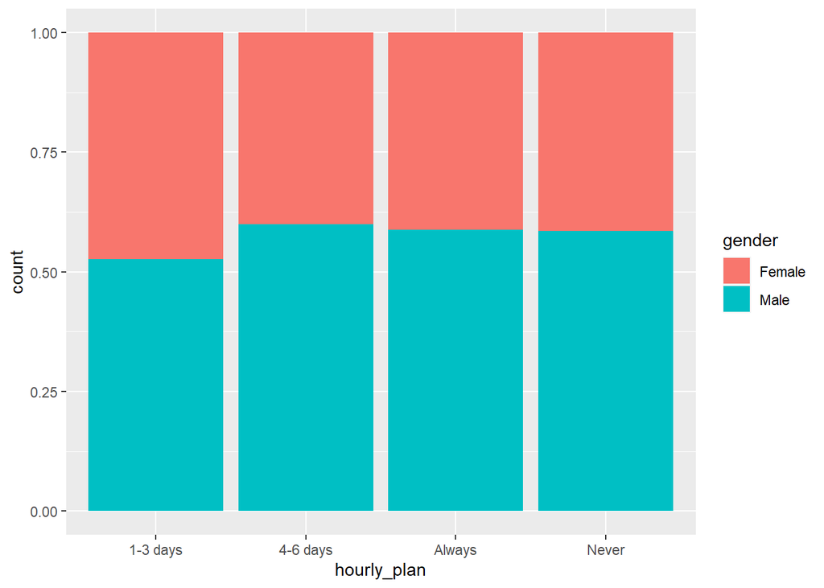

```r
p1 = ggplot(ghdata,aes(x = hourly_plan, fill = gender))
p1 + geom_bar(position = "fill")
```

$$H0: \mu = \mu_0 vs$$
$$H1 : \mu > \mu_0, \mu < \mu_0, \mu \neq
\mu_0$$

### 2.5.5 one sample t test

```r
tt = t.test(ghtable, var.equal = TRUE)
tt
```

```
##
##  One Sample t-test
##
## data:  ghtable
## t = 3.2074, df = 5, p-value = 0.0238
## alternative hypothesis: true mean is not equal to 0
## 95 percent confidence interval:
##   4.169722 37.830278
## sample estimates:
## mean of x
##        21
```

```r
tt$statistic
```

```
##        t
## 3.207447
```

### 2.5.6 wilcoxon test

```r
wilcox.test(ghtable, alternative = "greater")
```

```
##
##  Wilcoxon signed rank test with continuity correction
##
## data:  ghtable
## V = 21, p-value = 0.01776
## alternative hypothesis: true location is greater than 0
```

## 2.6 Will student who make hourly plan has a highe WAM?

Making hourly plan is a good habit for a student, it can assist them to finish their work in an efficient way, it may lead them to a higher WAM. However, some student may not have this kind of habit, but they also have a high WAM. I am going to test if there is a relation between WAM and making hourly plan.

```r
table(cleandat$hourly_plan, cleandat$wam)
```

```
##
##       0 1 5 8.2 34 50 55 60 62 65 65.3 66 67 68 69 70 70.5 70.67 72 73 73.4 74
##   No  1 0 0   1  1  4  0  2  0  1    0  0  0  2  1  5    1     0  2  2    0  1
##   yes 0 2 1   0  0  1  1  2  1  6    1  1  1  0  1  5    0     1  4  1    1  2
##
##       75 76 77 77.33 78 78.3 78.5 79 79.7 79.8 80 81 82 82.8 83 83.2 84.3 84.6
##   No   6  2  1     1  2    0    0  1    0    0  4  1  0    0  0    0    0    0
##   yes  9  0  0     0  7    1    1  1    1    1  5  3  1    1  1    1    1    1
##
##       85 87 87.2 89 89.1 90 90.06944444 90.55 91 91.2 92.2 99
##   No   2  0    1  1    1  0           1     1  1    1    1  2
##   yes  2  2    0  0    0  1           0     0  0    0    0  0
```

### 2.6.1 rename each wam in the dateset

```r
cleandat = cleandat %>% mutate(
 wam = stringr::str_to_title(wam),
  wam = recode(wam,
                  `34` = "PS",
                  `50` = "PS",
                  `55` = "PS",
                  `60` = "PS",
               `62` = "PS",
               `65` = "CR",
               `65.3` = "CR",
               `66` = "CR",
               `67` = "CR",
               `68` = "CR",
               `69` = "CR",
               `70` = "CR",
               `70.5` = "CR",
               `70.67` = "CR",
               `72` = "CR",
               `73` = "CR", `73.4` = "CR", `74` = "CR", `75` = "DI", `76`= "DI", `77`= "DI", `77.33`= "DI", `78`= "DI", `78.3`= "DI", `78.5` = "DI",`79`= "DI", `79.7`= "DI", `79.8`= "DI", `80`= "DI", `81`= "DI", `82` = "DI",`82.8` = "DI",`83`= "DI", `83.2`= "DI", `84.3`= "HD", `84.6`= "HD", `85`= "HD", `87`= "HD", `87.2`= "HD", `89`= "HD", `89.1`= "HD", `90`= "HD", `90.06944444`= "HD", `90.55`= "HD", `91`= "HD", `91.2`= "HD", `92.2`= "HD", `99`= "HD",),
  wam = forcats::fct_lump(wam, n =45))
table(cleandat$wam)
```

```
##
##   0   1   5 8.2  CR  DI  HD  PS
##   1   2   1   1  39  51  19  12
```

```r
table(cleandat$hourly_plan, cleandat$wam)
```

```
##
##        0  1  5 8.2 CR DI HD PS
##   No   1  0  0   1 15 18 12  7
##   yes  0  2  1   0 24 33  7  5
```